# Map Unit Key Web Coverage Service

2025-11-14

# Introduction

A web coverage service (WCS) is provided for the gSSURGO and gNATGSO [map unit key grids](https://nrcs.app.box.com/v/soils/folder/243464012908). These grids represent a rasterizaion of the gSSURGO and gNATSGO map unit keys for the conterminous United States at a resolution of 30m, referenced to an Albers Equal Area Conic (NAD83) coordinate reference system (EPSG:5070). Grids are LZW compressed and internally tiled for efficient random access. Cell values are map unit keys, encoded as unsigned 32-bit integers. The grid topology and cell values are identical to the rasters contained within the gSSURGO and gNATSGO file geo-databases (FGDB). The GeoTiff format is used to ensure maximum compatibility. Files are re-created as part of the annual SSURGO refresh cycle.

An experimental WCS is provided for raster soil survey (RSS) products at 10m resolution.

An experimental WCS is provided for STATSGO2 (2016) at 300m resolution.

An experimental WCS is provided for SSURGO in HI (EPSG:6628) and PR (EPSG:32161), at 30m resolution.

A similar WCS is provided for the [ISSR-800 soil property grids](https://casoilresource.lawr.ucdavis.edu/soil-properties/).

## Grid Selection

See the [`mukey.wcs`](http://ncss-tech.github.io/soilDB/docs/reference/mukey.wcs.html) and [`ISSR800.wcs`](http://ncss-tech.github.io/soilDB/docs/reference/ISSR800.wcs.html) manual pages for details.

Basic usage.

```r
# select gSSURGO grid, 30m resolution
x <- mukey.wcs(aoi = aoi, db = 'gssurgo', ...)

# select gNATSGO grid, 30m resolution
x <- mukey.wcs(aoi = aoi, db = 'gnatsgo', ...)

# select RSS grid, 10m resolution
x <- mukey.wcs(aoi = aoi, db = 'RSS', ...)

# select STATSGO2 grid, 300m resolution
x <- mukey.wcs(aoi = aoi, db = 'statsgo', ...)

# select various ISSR-800 grids, details below
x <- ISSR800.wcs(aoi = aoi, var = 'paws')
```

### gSSURGO

Excerpt from the [gSSURGO documentation](https://www.nrcs.usda.gov/wps/portal/nrcs/detail/soils/home/?cid=nrcs142p2_053628#release).

The gSSURGO Database is derived from the official Soil Survey Geographic (SSURGO) Database. SSURGO generally has the most detailed level of soil geographic data developed by the National Cooperative Soil Survey (NCSS) in accordance with NCSS mapping standards. The tabular data represent the soil attributes and are derived from properties and characteristics stored in the National Soil Information System (NASIS). The gSSURGO data were prepared by merging the traditional vector-based SSURGO digital map data and tabular data into statewide extents, adding a statewide gridded map layer derived from the vector layer, and adding a new value-added look up table (Valu1) containing “ready to map” attributes. The gridded map layer is a file geodatabase raster in an ArcGIS file geodatabase. The raster and vector map data have a statewide extent. The raster map data have a 10-meter cell size that approximates the vector polygons in an Albers Equal Area projection. Each cell (and polygon) is linked to a map unit identifier called the map unit key. A unique map unit key is used to link the raster cells and polygons to attribute tables. Due to file size, the raster layer for the conterminous United States is only available in a 30-meter resolution.

### gNATSGO

Excerpt from the [gNATSGO documentation](https://www.nrcs.usda.gov/wps/portal/nrcs/detail/soils/survey/geo/?cid=nrcseprd1464625).

The gNATSGO databases contain a raster of the soil map units and 70 related tables of soil properties and interpretations. They are designed to work with the SPSD gSSURGO ArcTools. Users can create full coverage thematic maps and grids of soil properties and interpretations for large geographic areas, such as the extent of a State or the conterminous United States. Please note that the State-wide geodatabases contain a 10 meter raster and the CONUS database contains a 30 meter raster.

The gNATSGO database is composed primarily of SSURGO data, but STATSGO2 data was used to fill in the gaps. The RSSs are newer product with relatively limited spatial extent. These RSSs were merged into the gNATSGO after combining the SSURGO and STATSGO2 data. The extent of RSS is expected to increase in the coming years.

### Raster Soil Survey

Excerpt from the [RSS documentation](https://www.nrcs.usda.gov/wps/portal/nrcs/detail/soils/survey/geo/?cid=nrcseprd1759022).

Raster Soil Survey is a reference to the products of soil survey work completed using digital soil mapping methodologies. Digital soil mapping is the production of georeferenced soil databases based on the quantitative relationships between soil measurements made in the field or laboratory and environmental data and may be represented as either discrete classes or continuous soil properties. Both digital and traditional soil mapping use a conceptual soil-landscape model as a means for organizing environmental information into discrete divisions. The primary difference between these two approaches is that digital methods exploit quantitative relationships of the environmental information, while traditional methods utilize a more subjective approach and the approximate relationships of the environmental information to spatially represent where the divisions are represented.

An experimental, 300m gridded representation of STATSGO 2 is provided by the SoilWeb web coverage service. This is not an official USDA-NRCS product.

### STATSGO

Excerpt from [STATSGO2 Documentation](https://www.nrcs.usda.gov/resources/data-and-reports/description-of-statsgo2-database).

The Digital General Soil Map of the United States or STATSGO2 is a broad-based inventory of soils and non-soil areas that occur in a repeatable pattern on the landscape and that can be cartographically shown at the scale mapped of 1:250,000 in the continental U.S., Hawaii, Puerto Rico, and the Virgin Islands and 1:1,000,000 in Alaska. The level of mapping is designed for broad planning and management uses covering state, regional, and multi-state areas. The U.S. General Soil Map is comprised of general soil association units and is maintained and distributed as a spatial and tabular dataset.

## Thematic Mapping

Thematic mapping or analysis of soil information requires connecting the grids to our tabular data sources, either using local files or Soil Data Access (SDA) web-service. The `soilDB` package provides many convenient interfaces to SDA. Note that SDA does not yet contain tabular data for the raster soil surveys.

## Caveats / Limitations

- Requests are limited to images sizes of 5000x5000 pixels, this is approximately 1x1 degrees at 30m.
- These instructions are based on the development version of [`soilDB`](https://github.com/ncss-tech/soilDB/), which has [recently switched over to `sf` and `terra` packages](https://github.com/ncss-tech/soilDB/blob/master/NEWS.md).

## Manually Creating bounding-boxes for WCS requests

The WCS interface functions `mukey.wcs` and `ISSR800.wcs` can automatically generate a bounding-box (BBOX) from most spatial data formats. However, sometimes it is more convenient to manually specify a BBOX created from a website or single point specified in WGS84 coordinates. [SoilWeb](https://casoilresource.lawr.ucdavis.edu/gmap/) provides two convenient keyboard shortcuts, available after clicking on the map interface:

- ‘b’ copy bounding-box, returned as:

  ```
  -118.6609 36.4820,-118.6609
  36.5972,-118.3979 36.5972,-118.3979 36.4820,-118.6609
  36.4820
  ```

- ‘p’ copy link to center coordinate, returned as: `https://casoilresource.lawr.ucdavis.edu/gmap/?loc=36.53964,-118.52943,z13`

Right-clicking anywhere in the map interface will also generate a link to those coordinates and zoom-level.

A SoilWeb-style BBOX can be directly converted into an `sf` object:

```r
library(sf)
library(soilDB)
library(terra)

# paste your BBOX text here
bb <- '-118.6609 36.4820,-118.6609 36.5972,-118.3979 36.5972,-118.3979 36.4820,-118.6609 36.4820'

# convert text -> WKT -> sf
wkt <- sprintf('POLYGON((%s))', bb)
x <- st_as_sfc(wkt)

# set coordinate reference system as GCS/WGS84
st_crs(x) <- 4326

# query WCS
mu <- mukey.wcs(x, db = 'gSSURGO')
```

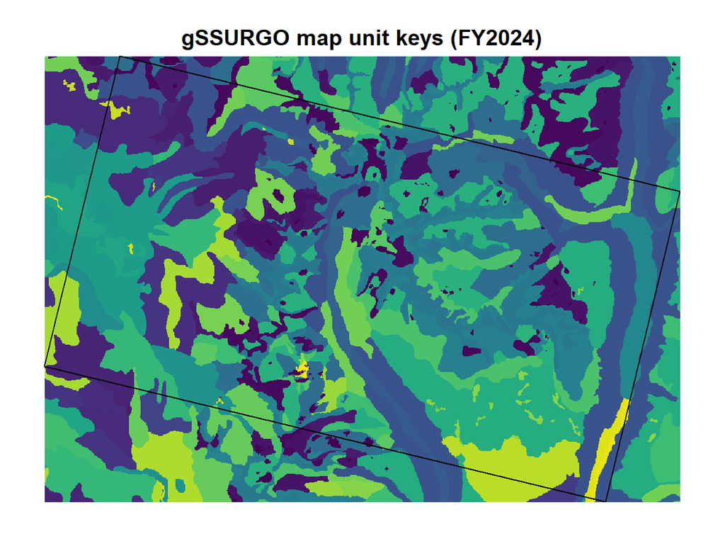

```r
# extract metadata for figure label
# see subsection below for details
.md <- metags(mu)
.title <- sprintf("%s (%s)", .md$value[1], .md$value[2])
plot(mu, legend = FALSE, axes = FALSE, main = .title)

# add original BBOX, after transforming to mukey grid CRS
plot(st_transform(x, 5070), add = TRUE)
```

### Metadata

Print attached metadata with the `terra::metags()` function. Currently, a short description and “vintage” are included. The gNATSGO, gSSURGO, and derivatives are typically created 2-3 months after the annual SSURGO refresh on October 1st of each year (beginning of US federal fiscal year).

| name | description | vintage |
| --- | --- | --- |
| value | gSSURGO map unit keys | FY2024 |
| domain |  |  |

A buffer applied to a [single WGS84 coordinate](https://casoilresource.lawr.ucdavis.edu/gmap/?loc=36.52578,-118.55639,z13) can create a BBOX:

```r
library(sf)
library(soilDB)

# example point, WGS84 coordinates
p <- st_as_sf(
  data.frame(
    x = -118.55639,
    y = 36.52578
  ),
  coords = c('x', 'y'),
  crs = 4326
)

# 1000m buffer applied to WGS84 coordinate
# radius defined in meters
b <- st_buffer(p, dist = units::set_units(1000, m))
b <- st_as_sf(b)

# query WCS
# result is in EPSG:5070
mu <- mukey.wcs(b, db = 'gSSURGO')
```

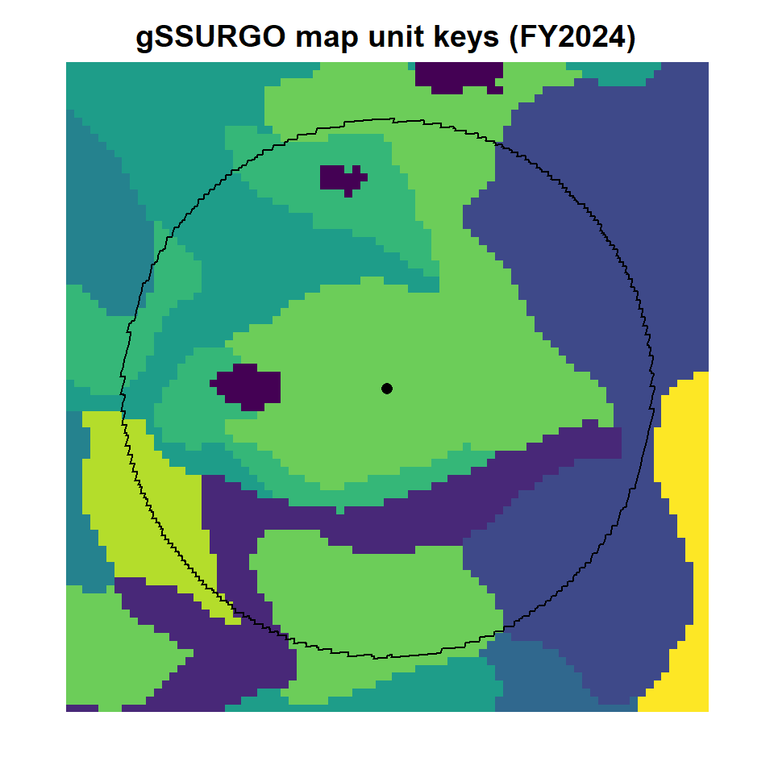

```r
# simple plot
.md <- metags(mu)
.title <- sprintf("%s (%s)", .md$value[1], .md$value[2])
plot(mu, legend = FALSE, axes = FALSE, main = .title)

# add buffer, after transforming to mukey grid CRS
plot(st_transform(b, 5070), add = TRUE)

# add original point, after transforming to mukey grid CRS
plot(st_transform(p, 5070), add = TRUE, pch = 16)
```

# Setup

Need the latest version of `soilDB` and `terra`, along with all packages specified below (CRAN versions fine).

```r
install.packages('soilDB')
remotes::install_github("ncss-tech/soilDB", dependencies = FALSE, upgrade = FALSE, build = FALSE)

# terra
install.packages('terra', repos = 'https://rspatial.r-universe.dev')
```

Load required packages.

```r
# latest from GitHub
# remotes::install_github("ncss-tech/soilDB", dependencies = FALSE)
library(soilDB)

# wrangling polygons and CRS transformations
library(sf)

# raster data / analysis
# need latest: install.packages('terra', repos='https://rspatial.r-universe.dev')
library(terra)

# raster visualization
library(rasterVis)

# figures
library(lattice)
library(tactile)

# soil classification
library(aqp)

# color palettes and manipulation
library(RColorBrewer)
library(colorspace)
```

# Map Unit Key Grids

```r
# make a bounding box and assign a CRS (4326: GCS, WGS84)
a <- st_bbox(
  c(xmin = -114.16, xmax = -114.08, ymin = 47.65, ymax = 47.68),
  crs = st_crs(4326)
)

# fetch gSSURGO map unit keys at native resolution (30m)
mu <- mukey.wcs(aoi = a, db = 'gssurgo')
```

```r
# check:
print(mu)
```

```
## class       : SpatRaster
## size        : 147, 219, 1  (nrow, ncol, nlyr)
## resolution  : 30, 30  (x, y)
## extent      : -1365495, -1358925, 2869245, 2873655  (xmin, xmax, ymin, ymax)
## coord. ref. : NAD83 / Conus Albers (EPSG:5070)
## source(s)   : memory
## varname     : file1b3017274df1
## categories  : mukey
## name        :   mukey
## min value   :  144983
## max value   : 1716001
```

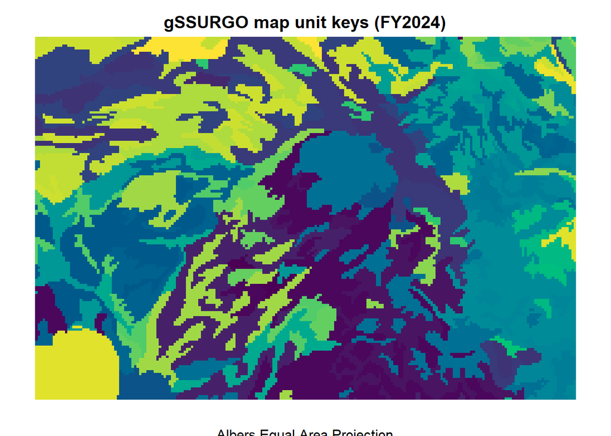

```r
# create title from metadata
.md <- metags(mu)
.title <- sprintf("%s (%s)", .md$value[1], .md$value[2])

# looks good
plot(
  mu,
  main = .title,
  sub = 'Albers Equal Area Projection',
  axes = FALSE,
  legend = FALSE,
  col = hcl.colors(100)
)
```

## SSURGO Polygons from SDA

It is possible to retrieve small areas of vector geometry (SSURGO polygons) from SDA with the `SDA_spatialQuery()` function. These data are stored and delivered in a geographic coordinate system (WGS84). Overlaying the SSURGO polygons and map unit key grids will require a simple transformation.

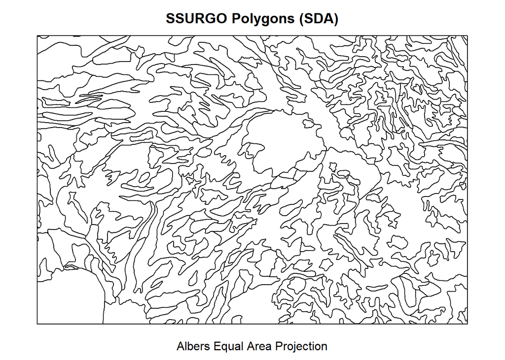

```r
# get intersecting SSURGO polygons from SDA
# result is a SpatVector object
# GCS WGS84
p <- SDA_spatialQuery(mu, what = 'mupolygon', geomIntersection = TRUE)

# transform to AEA coordinate reference system used by gSSURGO / gNATSGO
# this is EPSG:5070
p <- project(p, crs(mu))

par(mar = c(1, 0, 2, 0))
plot(p, main = 'SSURGO Polygons (SDA)', axes = FALSE)
mtext('Albers Equal Area Projection', side = 1, line = -0.5)
```

Overlay SSURGO polygons and 30m map unit key grid.

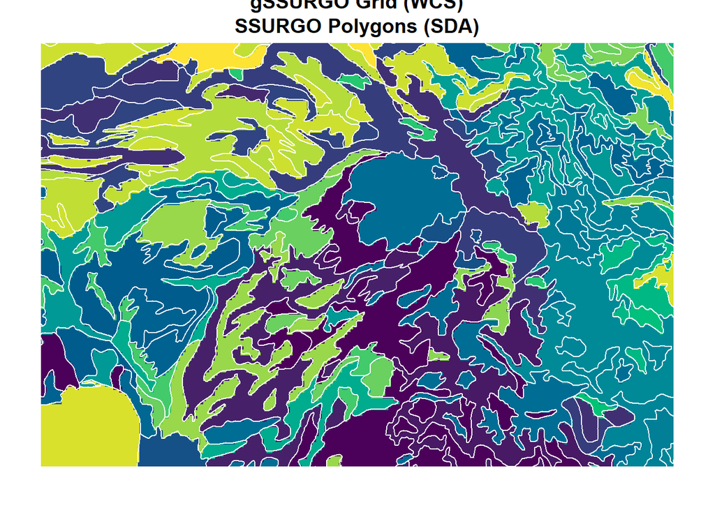

```r
par(mar = c(1, 0, 2, 0))
plot(mu, main = 'gSSURGO Grid (WCS)\nSSURGO Polygons (SDA)', col = hcl.colors(50), axes = FALSE, legend = FALSE)
plot(p, add = TRUE, border = 'white')

mtext('CONUS Albers Equal Area Projection (EPSG:5070)', side = 1, line = 1)
```

## Grid Resolution Specification

Requesting map unit key grids at a resolution other than 30m is possible, but only suitable for a quick “preview” of the data. For example, it is possible to get a much larger chunk of data by requesting grids at 800m. However, pixels are selected by nearest-neighbor and not generalized to the coarser scale. In short: don’t use the resulting data for anything other than a simple preview.

```r
# part of CA
# make a bounding box and assign a CRS (4326: GCS, WGS84)
a.CA <- st_bbox(
  c(xmin = -121, xmax = -120, ymin = 37, ymax = 38),
  crs = st_crs(4326)
)

# fetch gSSURGO map unit keys at ~~ 800m
# nearest-neighbor resampling = this is a "preview"
# result is a SpatRaster object
x.800 <- mukey.wcs(aoi = a.CA, db = 'gssurgo', res = 800)
```

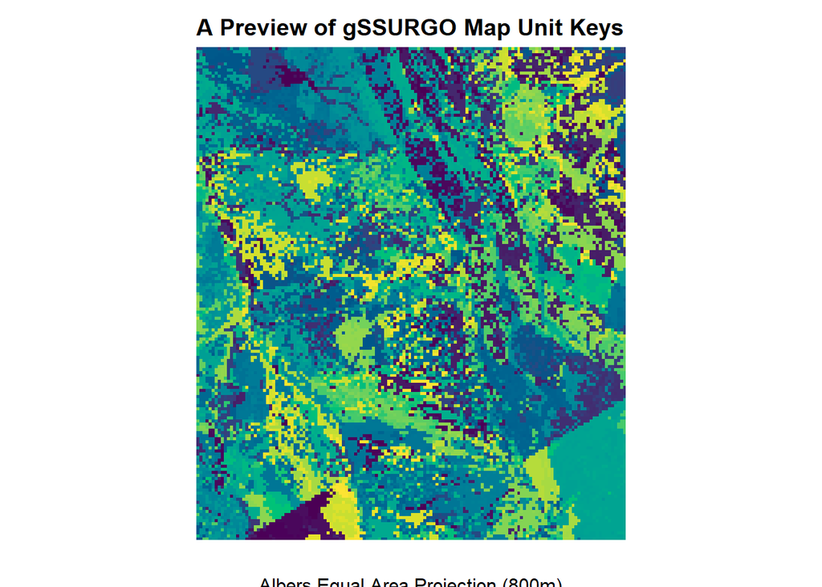

```r
# OK
plot(
  x.800,
  main = 'A Preview of gSSURGO Map Unit Keys',
  sub = 'Albers Equal Area Projection (800m)\nnearest-neighbor resampling',
  axes = FALSE,
  legend = FALSE,
  col = hcl.colors(100),
  )
```

## Raster Soil Survey Data

Note: tabular data for RSS are not yet available via SDA.

```r
# slightly larger than Coweeta RSS BBOX
# specified in EPSG:5070
a <- st_bbox(
  c(xmin = 1129000, xmax = 1135000, ymin = 1403000, ymax = 1411000),
  crs = st_crs(5070)
)

# convert to sf polygon for later use in figures
a <- st_as_sfc(a)

# gSSURGO grid: 30m resolution
(x <- mukey.wcs(a, db = 'gSSURGO', res = 30))
```

```
## class       : SpatRaster
## size        : 267, 200, 1  (nrow, ncol, nlyr)
## resolution  : 30, 30  (x, y)
## extent      : 1129005, 1135005, 1402995, 1411005  (xmin, xmax, ymin, ymax)
## coord. ref. : NAD83 / Conus Albers (EPSG:5070)
## source(s)   : memory
## varname     : file1b306bec27f2
## categories  : mukey
## name        :  mukey
## min value   : 545800
## max value   : 545887
```

```r
# gNATSGO grid: 30m resolution
(y <- mukey.wcs(a, db = 'gNATSGO', res = 30))
```

```
## class       : SpatRaster
## size        : 267, 200, 1  (nrow, ncol, nlyr)
## resolution  : 30, 30  (x, y)
## extent      : 1129005, 1135005, 1402995, 1411005  (xmin, xmax, ymin, ymax)
## coord. ref. : NAD83 / Conus Albers (EPSG:5070)
## source(s)   : memory
## varname     : file1b30ba27d0f
## categories  : mukey
## name        :   mukey
## min value   :  545800
## max value   : 3244759
```

```r
# RSS grid: 10m resolution
(z <- mukey.wcs(a, db = 'RSS', res = 10))
```

```
## class       : SpatRaster
## size        : 800, 600, 1  (nrow, ncol, nlyr)
## resolution  : 10, 10.0125  (x, y)
## extent      : 1129005, 1135005, 1402995, 1411005  (xmin, xmax, ymin, ymax)
## coord. ref. : NAD83 / Conus Albers (EPSG:5070)
## source(s)   : memory
## varname     : file1b306bb75b4
## categories  : mukey
## name        :   mukey
## min value   : 3244721
## max value   : 3244759
```

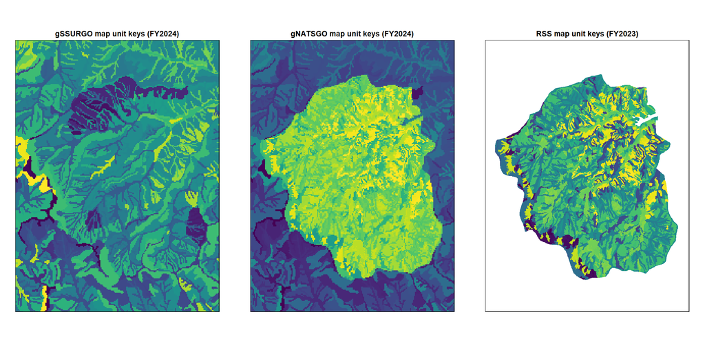

```r
# graphical comparison
par(mfcol = c(1, 3))

# gSSURGO
# create title from metadata
.md <- metags(x)
.title <- sprintf("%s (%s)", .md$value[1], .md$value[2])
plot(x, axes = FALSE, legend = FALSE, main = .title)
# original BBOX
plot(a, add = TRUE)

# gNATSGO
.md <- metags(y)
.title <- sprintf("%s (%s)", .md$value[1], .md$value[2])
plot(y, axes = FALSE, legend = FALSE, main = .title)
# original BBOX
plot(a, add = TRUE)

# RSS
.md <- metags(z)
.title <- sprintf("%s (%s)", .md$value[1], .md$value[2])
plot(z, axes = FALSE, legend = FALSE, main = .title, ext = x)
# original BBOX
plot(a, add = TRUE)
```

## STATSGO

Continuing from the example above.

```r
(statsgo <- mukey.wcs(a, db = 'statsgo', res = 300))
```

```
## class       : SpatRaster
## size        : 27, 20, 1  (nrow, ncol, nlyr)
## resolution  : 300, 300  (x, y)
## extent      : 1129005, 1135005, 1402995, 1411095  (xmin, xmax, ymin, ymax)
## coord. ref. : NAD83 / Conus Albers (EPSG:5070)
## source(s)   : memory
## varname     : file1b307dc91077
## categories  : mukey
## name        :  mukey
## min value   : 659074
## max value   : 664845
```

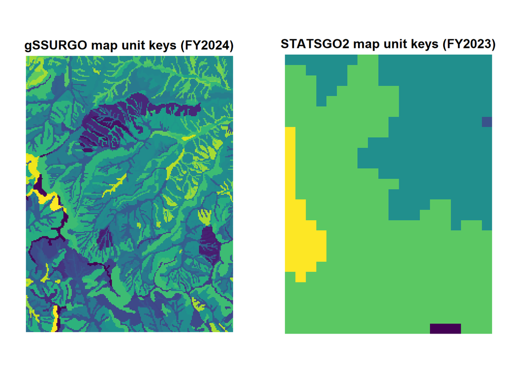

```r
# graphical comparison
par(mfcol = c(1, 2))

# gSSURGO
.md <- metags(x)
.title <- sprintf("%s (%s)", .md$value[1], .md$value[2])
plot(x, axes = FALSE, legend = FALSE, main = .title)

# STATSGO
.md <- metags(statsgo)
.title <- sprintf("%s (%s)", .md$value[1], .md$value[2])
plot(statsgo, axes = FALSE, legend = FALSE, main = .title)
```

## Hawaii SSURGO

An experimental, 30m SSURGO mukey WCS based on the EPSG:6628 coordinate reference system. The example bounding-box is centered on the [southern coast of Kauai](https://casoilresource.lawr.ucdavis.edu/gmap/?loc=21.97839,-159.61727,z13).

```r
# paste your BBOX text here
bb <- '-159.7426 21.9059,-159.7426 22.0457,-159.4913 22.0457,-159.4913 21.9059,-159.7426 21.9059'

# convert text -> WKT -> sf
wkt <- sprintf('POLYGON((%s))', bb)
x <- st_as_sfc(wkt)

# set coordinate reference system as GCS/WGS84
st_crs(x) <- 4326

# query WCS
mu <- mukey.wcs(x, db = 'hi_ssurgo')
```

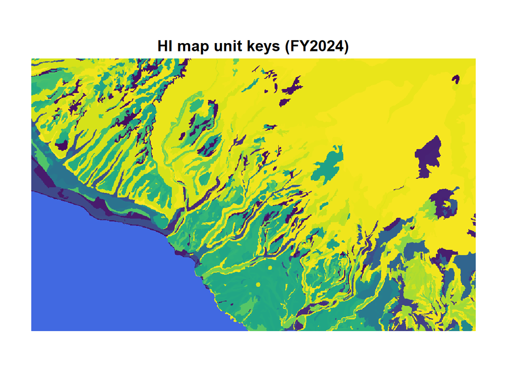

```r
# format title from metadata
.md <- metags(mu)
.title <- sprintf("%s (%s)", .md$value[1], .md$value[2])

# make NA (the ocean) blue
plot(mu, legend = FALSE, axes = FALSE, main = .title, colNA = 'royalblue')
```

```r
# # check mu names
# .is <- format_SQL_in_statement(cats(mu)[[1]]$mukey)
# .sql <- sprintf("SELECT mukey, muname FROM mapunit WHERE mukey IN %s", .is)
# knitr::kable(SDA_query(.sql))
```

## Puerto Rico SSURGO

An experimental, 30m SSURGO mukey WCS based on the EPSG:32161 coordinate reference system. The example bounding-box is centered on the [eastern coast of Puerto Rico](https://casoilresource.lawr.ucdavis.edu/gmap/?loc=18.24843,-65.67369,z13).

```r
# paste your BBOX text here
bb <- '-65.7741 18.1711,-65.7741 18.3143,-65.5228 18.3143,-65.5228 18.1711,-65.7741 18.1711'

# convert text -> WKT -> sf
wkt <- sprintf('POLYGON((%s))', bb)
x <- st_as_sfc(wkt)

# set coordinate reference system as GCS/WGS84
st_crs(x) <- 4326

# query WCS
mu <- mukey.wcs(x, db = 'pr_ssurgo')
```

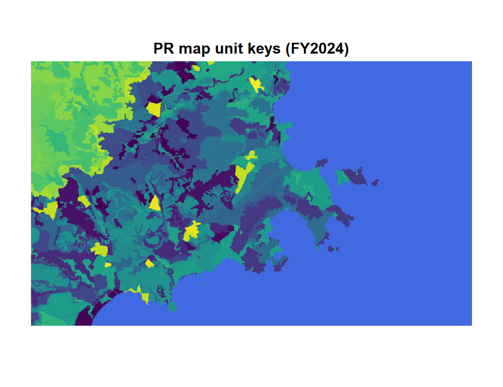

```r
# format title from metadata
.md <- metags(mu)
.title <- sprintf("%s (%s)", .md$value[1], .md$value[2])

# make NA (the ocean) blue
plot(mu, legend = FALSE, axes = FALSE, main = .title, colNA = 'royalblue')
```

```r
# # check mu names
# .is <- format_SQL_in_statement(cats(mu)[[1]]$mukey)
# .sql <- sprintf("SELECT mukey, muname FROM mapunit WHERE mukey IN %s", .is)
# knitr::kable(SDA_query(.sql))
```

# Thematic Mapping

The following example BBOX + resulting gSSURGO mukey grid will be used for the following examples

```r
# make a bounding box and assign a CRS (4326: GCS, WGS84)
a <- st_bbox(
  c(xmin = -114.16, xmax = -114.08, ymin = 47.65, ymax = 47.68),
  crs = st_crs(4326)
)

# convert bbox to sf geometry
a <- st_as_sfc(a)

# fetch gSSURGO map unit keys at native resolution (~30m)
mu <- mukey.wcs(aoi = a, db = 'gssurgo')
```

## Map Unit Aggregate Values

The Mapunit Aggregated Attribute table records a variety of soil attributes and interpretations that have been aggregated from the component level to a single value at the map unit level. They have been aggregated by one or more appropriate means in order to express a consolidated value or interpretation for the map unit as a whole.

Use the `get_SDA_muaggatt()` convenience function, or write a simple query in SQL and submit via `SDA_query()`.

```r
# copy example grid
mu2 <- mu

# extract RAT for thematic mapping
rat <- cats(mu2)[[1]]

# optionally use convenience function:
# * returns all fields from muagatt table
# * along with map unit name
# tab <- get_SDA_muaggatt(mukeys = as.numeric(rat$mukey), query_string = TRUE)


# the SQL is simple, only need a few columns from a single table
# safely create IN statement from vector of mukey
.sql <- sprintf(
  "SELECT mukey, aws050wta, aws0100wta FROM muaggatt WHERE mukey IN %s",
  format_SQL_in_statement(as.numeric(rat$mukey))
)

# run query, result is a data.frame
tab <- SDA_query(.sql)

# check
head(tab)
```

```
##    mukey aws050wta aws0100wta
## 1 144983      7.26      14.02
## 2 144984      7.31      14.14
## 3 144985      7.36      14.27
## 4 144986      7.06      13.19
## 5 145005      5.21       9.34
## 6 145009      5.49       9.16
```

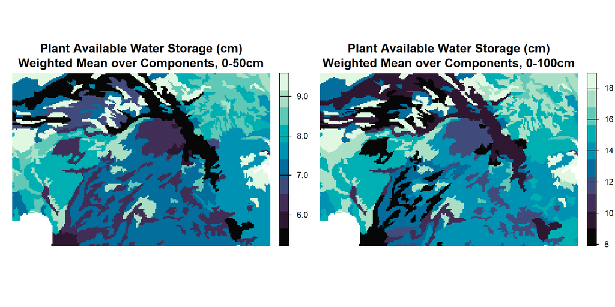

```r
# merge aggregate soil data into RAT
rat <- merge(rat, tab, by.x = 'mukey', by.y = 'mukey', sort = FALSE, all.x = TRUE)

# requires that grid cell ID (mukey) be numeric
rat$mukey <- as.integer(rat$mukey)
levels(mu2) <- rat

# convert grid + RAT -> stack of propery grids
# note explicit subset of returned grids, we don't need the mukey grid
aws <- catalyze(mu2)[[c('aws050wta', 'aws0100wta')]]

# simple plot, note scales are different
plot(aws, axes = FALSE, col = hcl.colors(10, 'mako'), main = c('Plant Available Water Storage (cm)\nWeighted Mean over Components, 0-50cm', 'Plant Available Water Storage (cm)\nWeighted Mean over Components, 0-100cm'))
```

## Interpretations for Soil Suitability / Limitation

Use the `get_SDA_interpretation()` convenience function.

```r
# copy example grid
mu2 <- mu

# extract RAT for thematic mapping
rat <- cats(mu2)[[1]]

rules <- c('ENG - Construction Materials; Roadfill', 'AWM - Irrigation Disposal of Wastewater')

tab <- get_SDA_interpretation(
  rulename = rules,
  method = "Weighted Average",
  mukeys = as.numeric(rat$mukey)
)

# check
head(tab)
```

```
##   areasymbol musym                                                            muname   mukey
## 1      MT629 1044D Eaglewing gravelly silt loam, 8 to 15 percent slopes, lake effect 1715935
## 2      MT629     W                                                             Water  145385
## 3      MT629   130                           Polson silt loam, 0 to 2 percent slopes  145017
## 4      MT629   129                                                      Pits, gravel  145015
## 5      MT629   126                         Ninepipe silt loam, 0 to 2 percent slopes  145012
## 6      MT629   125                      Niarada-Kerl complex, 8 to 15 percent slopes  145011
##   rating_ENGConstructionMaterialsRoadfill rating_AWMIrrigationDisposalofWastewater
## 1                                    0.83                                     0.99
## 2                                      NA                                       NA
## 3                                    0.04                                     0.90
## 4                                    1.00                                     1.00
## 5                                    0.00                                     0.15
## 6                                    0.88                                     0.96
##   class_ENGConstructionMaterialsRoadfill class_AWMIrrigationDisposalofWastewater
```

[output cut: 20 more lines]

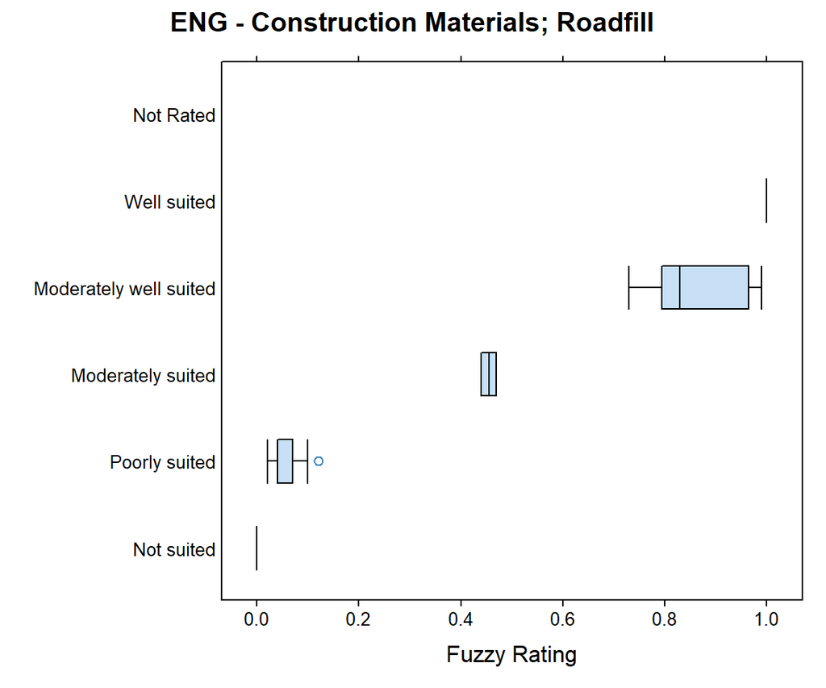

```r
# set factor levels
tab$class_ENGConstructionMaterialsRoadfill <- factor(
  tab$class_ENGConstructionMaterialsRoadfill,
  levels = c('Not suited', 'Poorly suited', 'Moderately suited', 'Moderately well suited', 'Well suited', 'Not Rated'),
  ordered = TRUE
)

bwplot(
  class_ENGConstructionMaterialsRoadfill ~ rating_ENGConstructionMaterialsRoadfill,
  data = tab,
  xlab = 'Fuzzy Rating',
  main = 'ENG - Construction Materials; Roadfill',
  par.settings = tactile.theme()
)
```

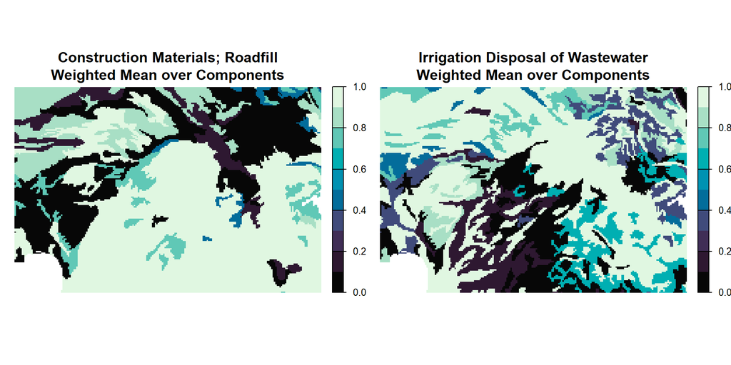

```r
# merge aggregate soil data into RAT
rat <- merge(rat, tab, by.x = 'mukey', by.y = 'mukey', sort = FALSE, all.x = TRUE)

# requires that grid cell ID (mukey) be numeric
rat$mukey <- as.integer(rat$mukey)
levels(mu2) <- rat


# convert grid + RAT -> stack of property grids
# note explicit subset of returned grids, we don't need the mukey grid
vars <- c('rating_ENGConstructionMaterialsRoadfill', 'rating_AWMIrrigationDisposalofWastewater')
rating <- catalyze(mu2)[[vars]]

# simple plot, note scales are different
plot(rating, axes = FALSE, col = hcl.colors(10, 'mako'), main = c('Construction Materials; Roadfill\nWeighted Mean over Components', 'Irrigation Disposal of Wastewater\nWeighted Mean over Components'))
```

## Component level properties

Steel corrosion potential.

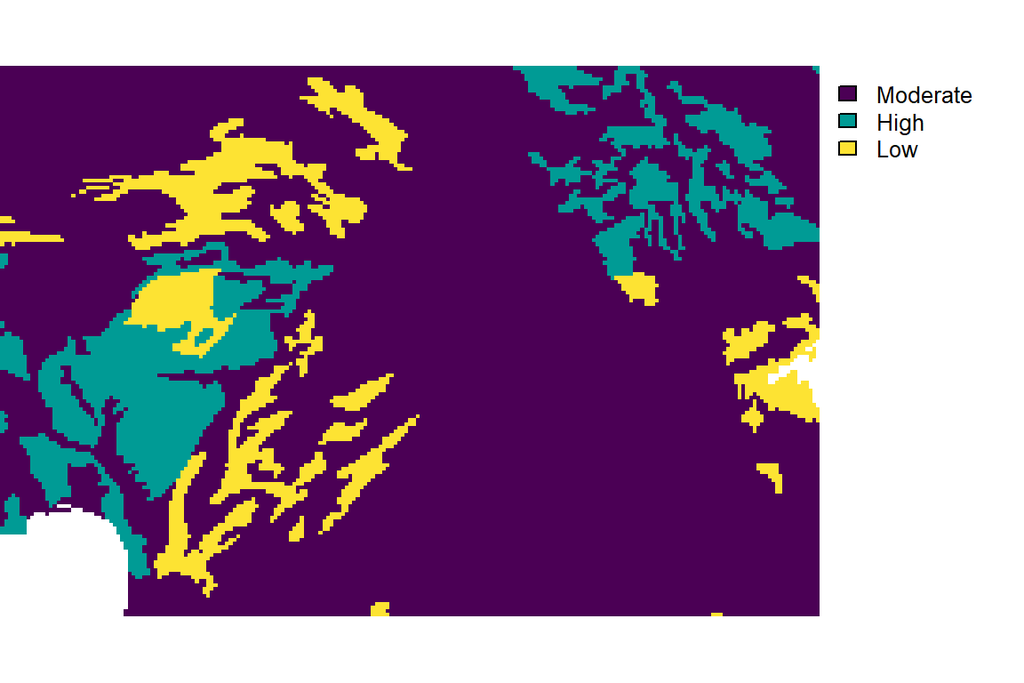

```r
# copy example grid
mu2 <- mu

# extract RAT for thematic mapping
rat <- cats(mu2)[[1]]

tab <- get_SDA_property(property = 'Corrosion of Steel',
                        method = 'DOMINANT CONDITION',
                        mukeys = as.integer(rat$mukey)
)


# convert to factor and set levels in logical order
tab$corsteel <- factor(tab$corsteel, levels = c('Low', 'Moderate', 'High'))

# merge aggregate soil data into RAT
rat <- merge(rat, tab, by.x = 'mukey', by.y = 'mukey', sort = FALSE, all.x = TRUE)

# requires that grid cell ID (mukey) be numeric
rat$mukey <- as.integer(rat$mukey)
levels(mu2) <- rat

# set active category to corsteel
activeCat(mu2) <- 'corsteel'

# plot
plot(mu2, axes = FALSE, col = hcl.colors(3), mar = c(0, 0, 0, 6))
```

Simplified component parent material group.

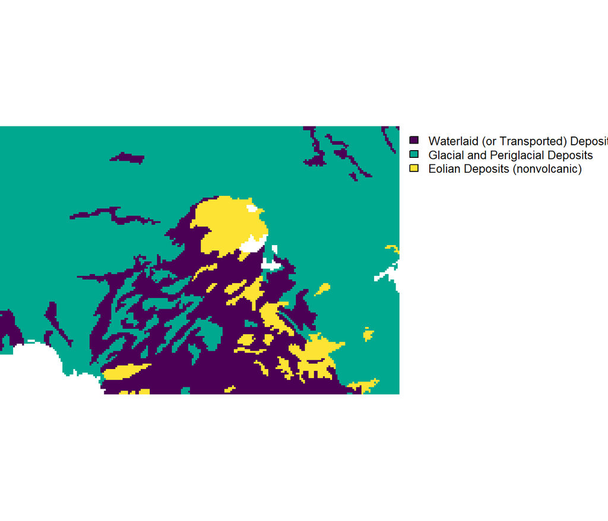

```r
# copy example grid
mu2 <- mu

# extract RAT for thematic mapping
rat <- cats(mu2)[[1]]

# simplified parent material group name
tab <- get_SDA_pmgroupname(mukeys = as.integer(rat$mukey))

# merge aggregate soil data into RAT
rat <- merge(rat, tab, by.x = 'mukey', by.y = 'mukey', sort = FALSE, all.x = TRUE)

# requires that grid cell ID (mukey) be numeric
rat$mukey <- as.integer(rat$mukey)
levels(mu2) <- rat

# set active category to corsteel
activeCat(mu2) <- 'pmgroupname'
plot(mu2, axes = FALSE, col = hcl.colors(10), mar = c(0, 0, 0, 12))
```

Hydric Rating.

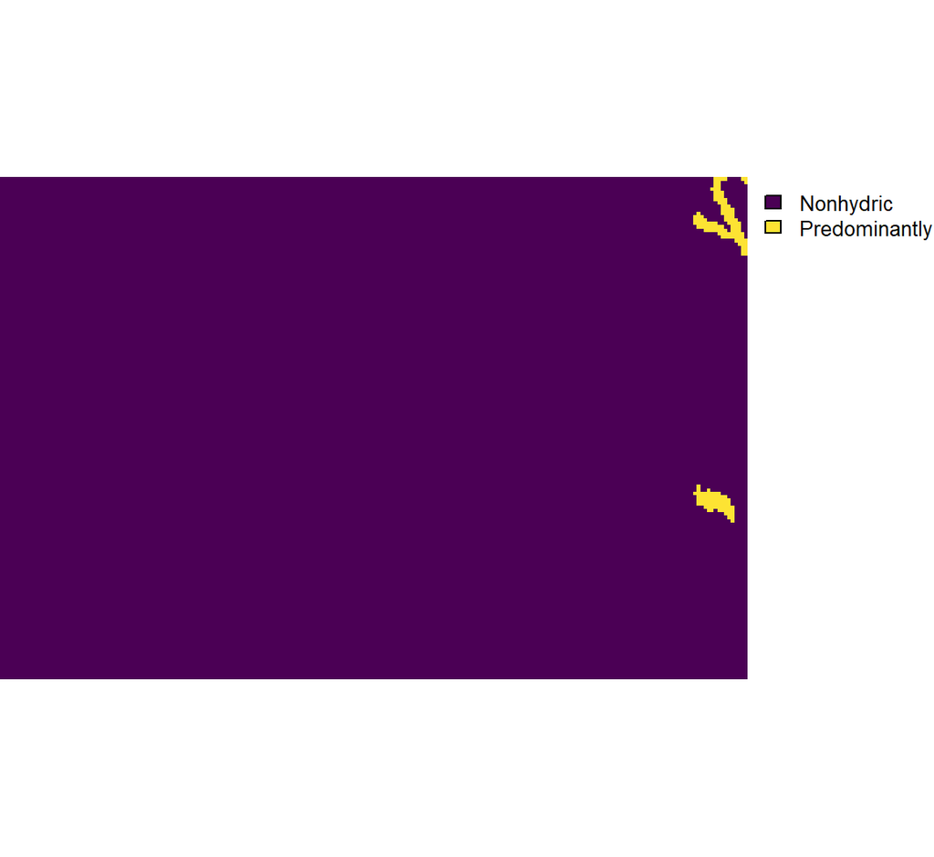

```r
# copy example grid
mu2 <- mu

# extract RAT for thematic mapping
rat <- cats(mu2)[[1]]

# simplified parent material group name
tab <- get_SDA_hydric(mukeys = as.integer(rat$mukey))

# merge aggregate soil data into RAT
rat <- merge(rat, tab, by.x = 'mukey', by.y = 'mukey', sort = FALSE, all.x = TRUE)

# requires that grid cell ID (mukey) be numeric
rat$mukey <- as.integer(rat$mukey)
levels(mu2) <- rat

# set active category to corsteel
activeCat(mu2) <- 'HYDRIC_RATING'
plot(mu2, axes = FALSE, col = hcl.colors(10), mar = c(0, 0, 0, 6))
```

## Several horizon-level soil properties

The [`get_SDA_property()`](http://ncss-tech.github.io/soilDB/reference/get_SDA_property.html) function from `soilDB` is convenient interface to aggregated SSURGO/STATSGO tabular data via SDA.

Setup a new AOI for the following examples.

```r
# https://casoilresource.lawr.ucdavis.edu/gmap/?loc=36.57666,-96.70175,z14
# make a bounding box and assign a CRS (4326: GCS, WGS84)
a <- st_bbox(
  c(xmin = -96.7696, xmax = -96.6477, ymin = 36.5477, ymax = 36.6139),
  crs = st_crs(4326)
)

# fetch gSSURGO map unit keys at native resolution (~30m)
mu <- mukey.wcs(aoi = a, db = 'gssurgo')
```

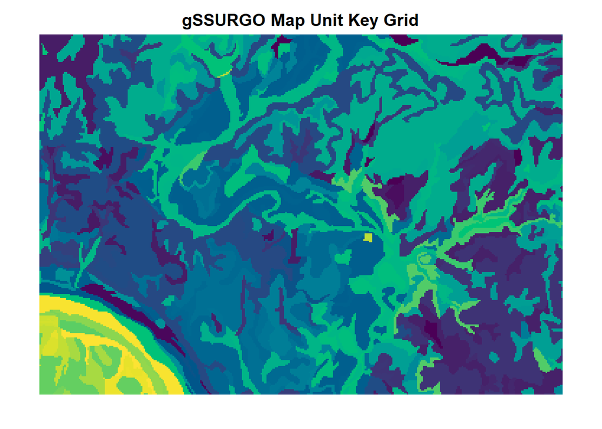

```r
# check: OK
plot(
  mu,
  legend = FALSE,
  axes = FALSE,
  col = hcl.colors(100),
  main = 'gSSURGO Map Unit Key Grid'
)
```

Derive aggregate soil properties, merge with raster attribute table (RAT).

```r
# extract RAT for thematic mapping
rat <- cats(mu)[[1]]

# variables of interest
vars <- c("dbthirdbar_r", "awc_r", "ph1to1h2o_r")

# get / aggregate specific horizon-level properties from SDA
# be sure to see the manual page for this function
p <-  get_SDA_property(property = vars,
                       method = "Dominant Component (Numeric)",
                       mukeys = as.integer(rat$mukey),
                       top_depth = 0,
                       bottom_depth = 25)


# check: OK
head(p)
```

```
##    mukey areasymbol musym                                                                   muname
## 1 623396      OK113     1                          Apperson silty clay loam, 1 to 3 percent slopes
## 2 623399      OK113     4                                        Coyle loam, 1 to 3 percent slopes
## 3 623402      OK113     7 Keokuk very fine sandy loam, 0 to 1 percent slopes, occasionally flooded
## 4 623405      OK113    10                                 Bethany silt loam, 1 to 3 percent slopes
## 5 623406      OK113    11                                 Bethany silt loam, 3 to 5 percent slopes
## 6 623407      OK113    12                          Bethany-Pawhuska complex, 1 to 5 percent slopes
##   dbthirdbar_r  awc_r ph1to1h2o_r
## 1       1.4500 0.1800       6.148
## 2       1.4000 0.1800       5.700
## 3       1.4316 0.1716       7.300
## 4       1.3500 0.2000       6.200
## 5       1.3000 0.2000       6.300
## 6       1.3400 0.2000       6.300
```

```r
# convert areasymbol into a factor easy plotting later
p$areasymbol <- factor(p$areasymbol)

# merge aggregate soil data into RAT
rat <- merge(rat, p, by.x = 'mukey', by.y = 'mukey', sort = FALSE, all.x = TRUE)

# requires that grid cell ID (mukey) be numeric
rat$mukey <- as.integer(rat$mukey)
levels(mu) <- rat

# result is a grid of map unit keys + RAT
```

Plant available water 0-25cm.

```r
# list variables in the RAT
names(cats(mu)[[1]])
```

```
## [1] "mukey"        "ID"           "areasymbol"   "musym"        "muname"       "dbthirdbar_r"
## [7] "awc_r"        "ph1to1h2o_r"
```

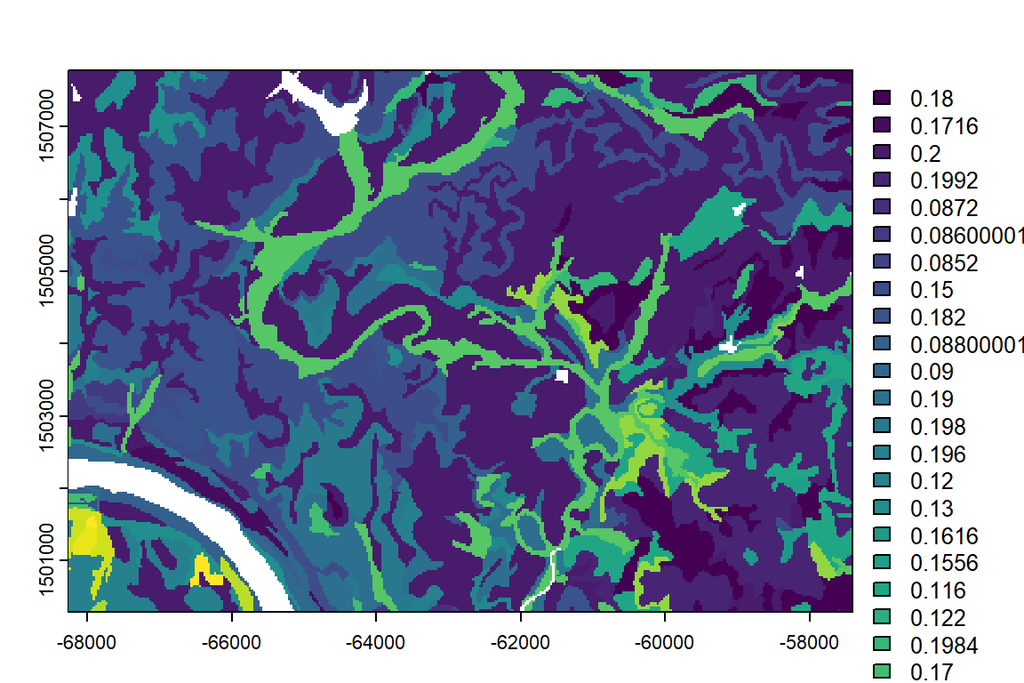

```r
activeCat(mu) <- 'awc_r'
plot(mu)
```

Plot aggregated soil properties.

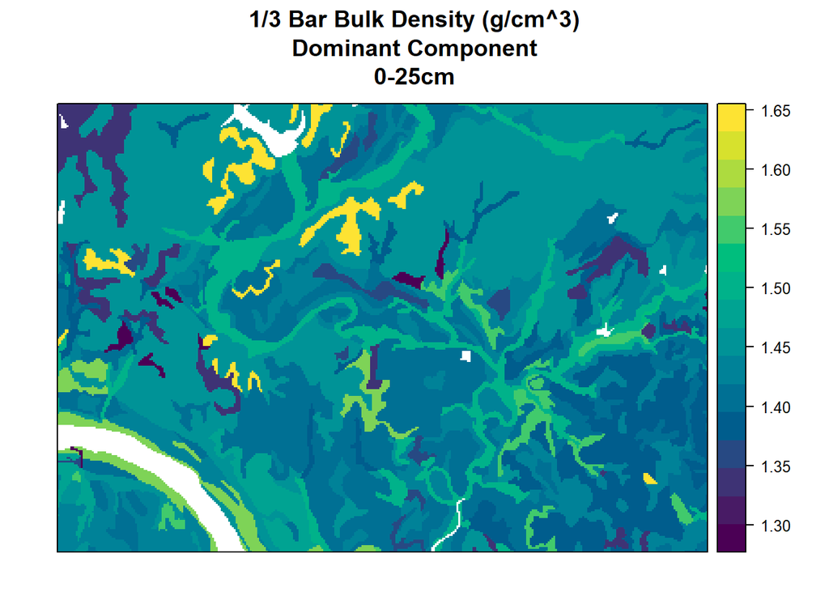

```r
# reset the active category to 1
# this will ensure that all variables in the RAT will be converted by catalyze(mu)
activeCat(mu) <- 1

# convert mukey grid + RAT -> stack of numerical grids
mu.stack <- catalyze(mu)

# keep only properties / remove IDs
mu.stack <- mu.stack[[vars]]


# note implicit simplification via maxpixels
levelplot(
  mu.stack[['dbthirdbar_r']],
  main = '1/3 Bar Bulk Density (g/cm^3)\nDominant Component\n0-25cm',
  margin = FALSE,
  scales = list(draw = FALSE),
  col.regions = hcl.colors,
  maxpixels = 1e5
)
```

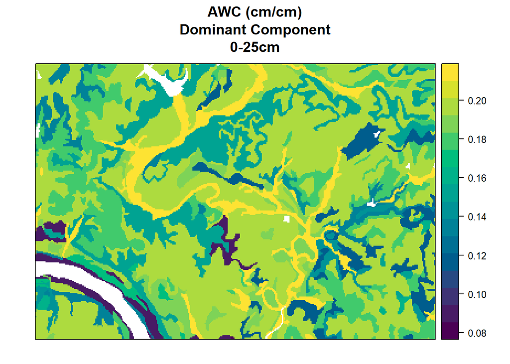

```r
levelplot(
  mu.stack[['awc_r']],
  main = 'AWC (cm/cm)\nDominant Component\n0-25cm',
  margin = FALSE,
  scales = list(draw = FALSE),
  col.regions = hcl.colors,
  maxpixels = 1e5
)
```

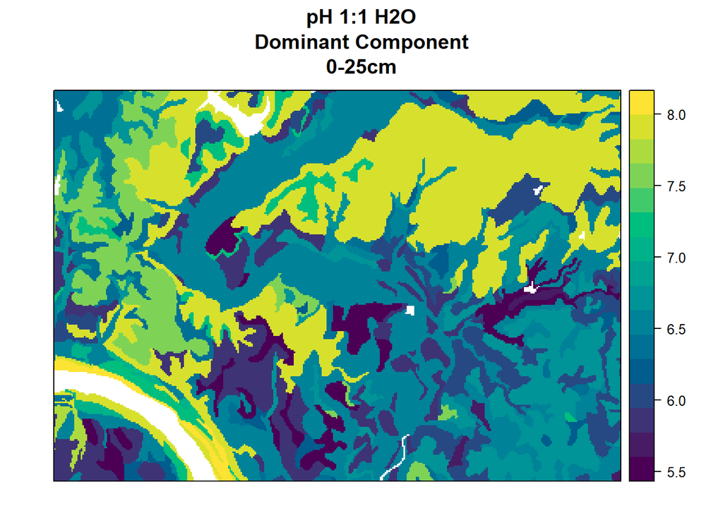

```r
levelplot(
  mu.stack[['ph1to1h2o_r']],
  main = 'pH 1:1 H2O\nDominant Component\n0-25cm',
  margin = FALSE,
  scales = list(draw = FALSE),
  col.regions = hcl.colors,
  maxpixels = 1e5
)
```

## Sand, Silt, and Clay at a Soil Survey Area Boundary

A not so great SSA join (1979 vs 2004).

Setup BBOX and query mukey WCS.

```r
# extract a BBOX like this from SoilWeb by pressing "b"
bb <- '-91.6853 36.4617,-91.6853 36.5281,-91.5475 36.5281,-91.5475 36.4617,-91.6853 36.4617'
wkt <- sprintf('POLYGON((%s))', bb)

# init sf object from WKT
x <- st_as_sfc(wkt)

# assign GCS WGS84 coordinate reference system
st_crs(x) <- 4326

# get gSSURGO grid here
mu <- mukey.wcs(aoi = x, db = 'gssurgo')
```

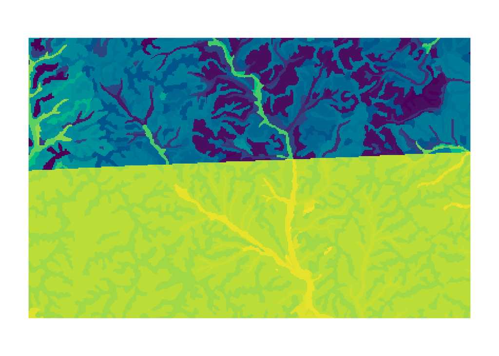

```r
# note SSA boundary
plot(mu, legend = FALSE, axes = FALSE, col = hcl.colors(100))
```

Derive aggregate sand, silt, clay (RV) values from the largest component, taking the weighted mean over 25-50cm depth interval.

```r
# extract RAT for thematic mapping
rat <- cats(mu)[[1]]

# variables of interest
vars <- c("sandtotal_r","silttotal_r","claytotal_r")

# get thematic data from SDA
# dominant component
# depth-weighted average
# sand, silt, clay (RV)
p <-  get_SDA_property(property = vars,
                       method = "Dominant Component (Numeric)",
                       mukeys = as.integer(rat$mukey),
                       top_depth = 25,
                       bottom_depth = 50)


# check
head(p)
```

```
##     mukey areasymbol musym                                                              muname
## 1  691980      MO091 73306               Gressy-Gatewood complex, 3 to 8 percent slopes, rocky
## 2 2502332      MO149 73321                       Alred-Gatewood complex, 1 to 8 percent slopes
## 3 2502334      MO149 73322                      Alred-Gatewood complex, 8 to 15 percent slopes
## 4 2503322      MO149 76002 Batcave-Farewell complex, 1 to 3 percent slopes, frequently flooded
## 5 2503473      MO149 76046             Secesh silt loam, 1 to 3 percent slopes, rarely flooded
## 6 2503476      MO149 76047    Secesh-Tilk complex, 1 to 3 percent slopes, occasionally flooded
##   sandtotal_r silttotal_r claytotal_r
## 1      23.000      59.000      18.000
## 2      28.692      51.108      20.200
## 3      28.692      51.108      20.200
## 4      40.000      40.000      20.000
## 5      25.648      49.000      25.352
## 6      26.908      48.076      25.016
```

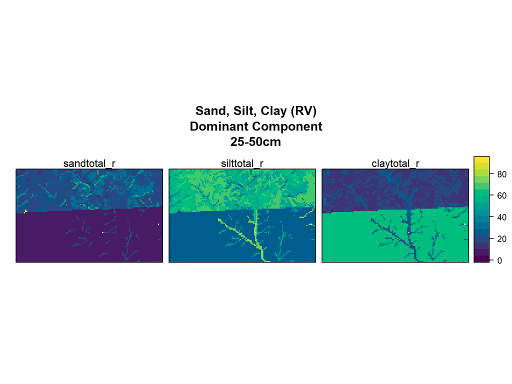

```r
# merge aggregate soil data into RAT
rat <- merge(rat, p, by.x = 'mukey', by.y = 'mukey', sort = FALSE, all.x = TRUE)

# requires that grid cell ID (mukey) be numeric
rat$mukey <- as.integer(rat$mukey)
levels(mu) <- rat

# convert mukey grid + RAT -> stack of numerical grids
# retaining only sand, silt, clay via [[vars]]
ssc <- catalyze(mu)[[vars]]

# graphical check
# note implicit simplification via maxpixels
levelplot(
  ssc,
  main = 'Sand, Silt, Clay (RV)\nDominant Component\n25-50cm',
  margin = FALSE,
  scales = list(draw = FALSE),
  col.regions = hcl.colors,
  maxpixels = 1e4,
  layout = c(3, 1)
)
```

Convert to soil texture class of <2mm fraction.

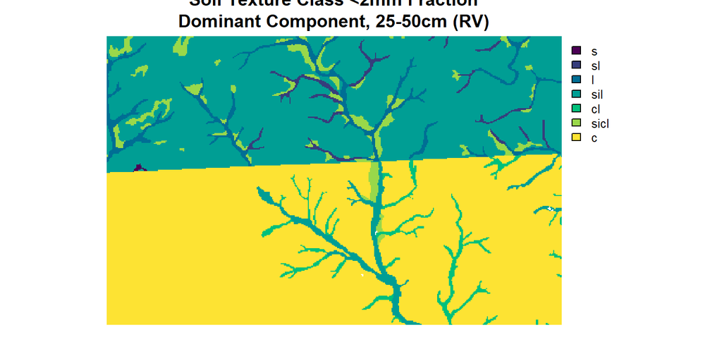

```r
# create a new grid by copy
# we will place soil texture classes into this grid
texture.class <- ssc[[1]]
names(texture.class) <- 'soil.texture'

# assign soil texture classes for the fine earth fraction
# using sand and clay percentages
values(texture.class) <- ssc_to_texcl(
  sand = values(ssc[['sandtotal_r']]),
  clay = values(ssc[['claytotal_r']]),
  droplevels = FALSE
)

plot(texture.class, col = hcl.colors(50), axes = FALSE, main = 'Soil Texture Class <2mm Fraction\nDominant Component, 25-50cm (RV)')
```

# Other Relevant WCS

## ISSR-800

Available data sets. (TODO: there are more more to add, including NCCPI)

```r
WCS_details(wcs = 'ISSR800')
```

| var | description |
| --- | --- |
| caco3_kg_sq_m | Total CaCO3 (kg/m^2) |
| cec_025cm | CEC at pH 7 0-25cm depth (cmol[+]/kg) |
| cec_050cm | CEC at pH 7 0-50cm depth (cmol[+]/kg) |
| cec_05cm | CEC at pH 7 0-5cm depth (cmol[+]/kg) |
| clay_025cm | clay percent 0-25cm depth |
| clay_05cm | clay percent 0-5cm depth |
| clay_2550cm | clay percent 25-50cm depth |
| clay_3060cm | clay percent 30-60cm depth |
| drainage_class | Soil Drainage Class |
| ec_025cm | EC 0-25cm depth (dS/m) |
| ec_05cm | EC 0-5cm depth (dS/m) |
| greatgroup | Soil Taxonomy: Greatgroup |
| hydgrp | Hydrologic Soil Group |
| lcc_irrigated | Land Capability Class, irrigated |
| lcc_nonirrigated | Land Capability Class, non-irrigated |
| om_kg_sq_m | Total Soil Organic Matter (kg/m^2) |
| paws | total plant available water storage (cm water) |
| paws_025cm | plant available water storage 0-25cm depth (cm water) |
| paws_050cm | plant available water storage 0-50cm depth (cm water) |
| ph_025cm | pH 1:1 H2O 0-25cm depth |
| ph_05cm | pH 1:1 H2O 0-5cm depth |
| ph_2550cm | pH 1:1 H2O 25-50cm depth |
| ph_3060cm | pH 1:1 H2O 30-60cm depth |
| sand_025cm | sand percent 0-25cm depth |
| sand_05cm | sand percent 0-5cm depth |
| sand_2550cm | sand percent 25-50cm depth |
| sand_3060cm | sand percent 30-60cm depth |
| sar | SAR, entire profile |
| series_name | Soil Series Name |
| silt_025cm | silt percent 0-25cm depth |
| silt_05cm | silt percent 0-5cm depth |
| silt_2550cm | silt percent 25-50cm depth |
| silt_3060cm | silt percent 30-60cm depth |
| soilorder | Soil Taxonomy: Soil Order |
| ssurgo_pct | SSURGO data available, fraction of 800x800m grid cell |
| statsgo_pct | STATSGO data available, fraction of 800x800m grid cell |
| str | Soil Temperature Regime |
| suborder | Soil Taxonomy: Suborder |
| texture_025cm | Soil Texture Class, 0-25cm |
| texture_05cm | Soil Texture Class, 0-5cm |
| texture_2550cm | Soil Texture Class, 25-50cm |
| weg | Wind Erodibility Group |
| wei | Wind Erodibility Index |

Examples for a broad slice of California

```r
# make a bounding box and assign a CRS (4326: GCS, WGS84)
a.CA <- st_bbox(
  c(xmin = -121, xmax = -120, ymin = 37, ymax = 38),
  crs = st_crs(4326)
)

# convert bbox to sf geometry
a.CA <- st_as_sfc(a.CA)

# floating point grids
paws_total <- ISSR800.wcs(aoi = a.CA, var = 'paws')
paws_025cm <- ISSR800.wcs(aoi = a.CA, var = 'paws_025cm')
paws_050cm <- ISSR800.wcs(aoi = a.CA, var = 'paws_050cm')

pH_05cm <- ISSR800.wcs(aoi = a.CA, var = 'ph_05cm')
pH_3060cm <- ISSR800.wcs(aoi = a.CA, var = 'ph_3060cm')

clay_05cm <- ISSR800.wcs(aoi = a.CA, var = 'clay_05cm')
clay_3060cm <- ISSR800.wcs(aoi = a.CA, var = 'clay_3060cm')
silt_3060cm <- ISSR800.wcs(aoi = a.CA, var = 'silt_3060cm')
sand_3060cm <- ISSR800.wcs(aoi = a.CA, var = 'sand_3060cm')

## NA encoding issues
# 0 is a real value
sar <- ISSR800.wcs(aoi = a.CA, var = 'sar')

# 16bit integer grids
wei <- ISSR800.wcs(aoi = a.CA, var = 'wei')

# 8bit unsigned (BYTE) grids with RAT
drainage_class <- ISSR800.wcs(aoi = a.CA, var = 'drainage_class')
weg <- ISSR800.wcs(aoi = a.CA, var = 'weg')
str <- ISSR800.wcs(aoi = a.CA, var = 'str')

# metadata
metags(sar)
```

```
##          name               value domain
## 1 description SAR, entire profile
## 2     vintage              FY2024
```

Check to see if aggregated sand + silt + clay is roughly = 100%. Almost. This isn’t surprising since each component of soil texture is aggregated separately.

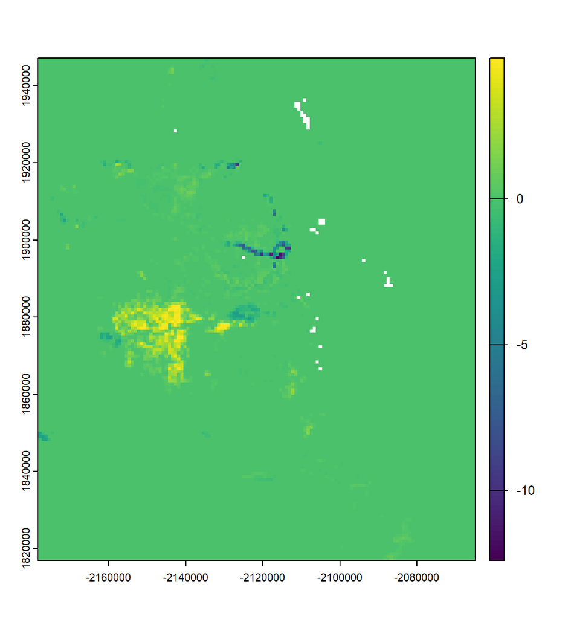

```r
z <- sand_3060cm + silt_3060cm + clay_3060cm
plot(z - 100)
```

Soil texture class 25-50cm.

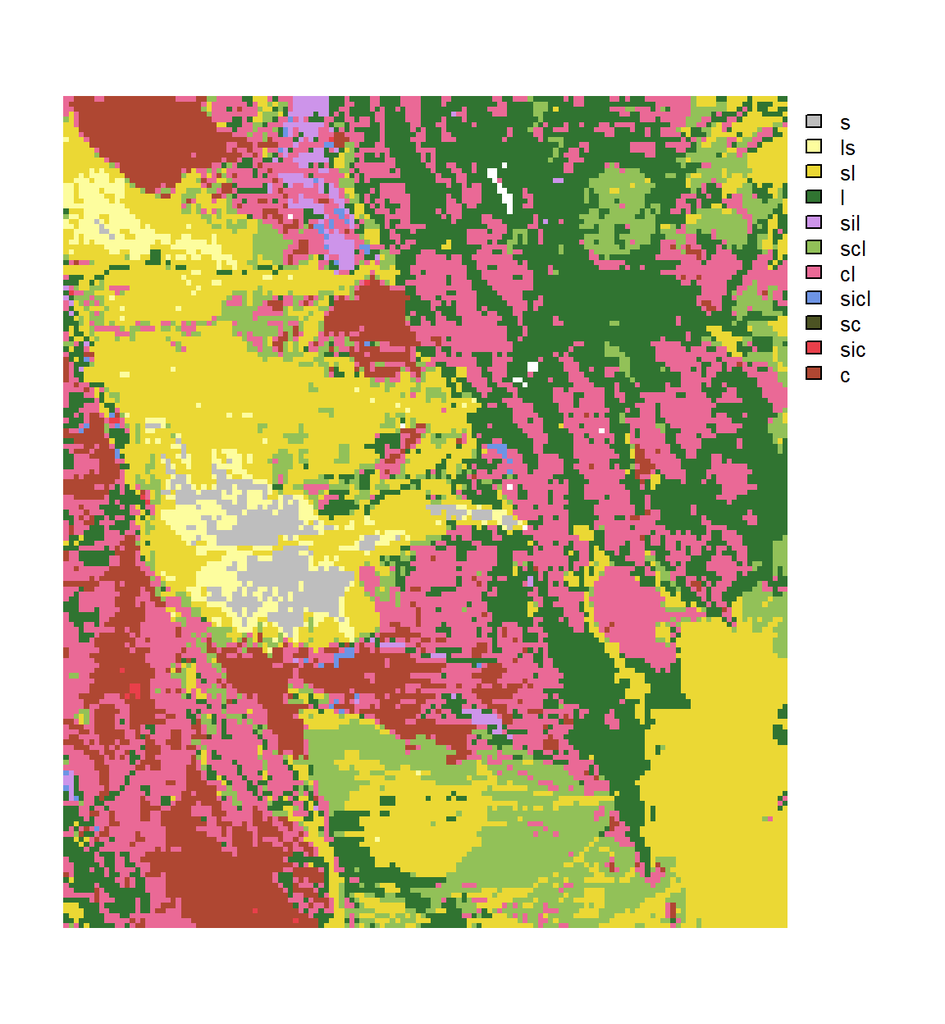

```r
texture_2550cm <- ISSR800.wcs(aoi = a.CA, var = 'texture_2550cm')

# plot using SoilWeb soil texture class colors
# preset by ISSR800.wcs()
plot(texture_2550cm, axes = FALSE)
```

Other soil properties of interest.

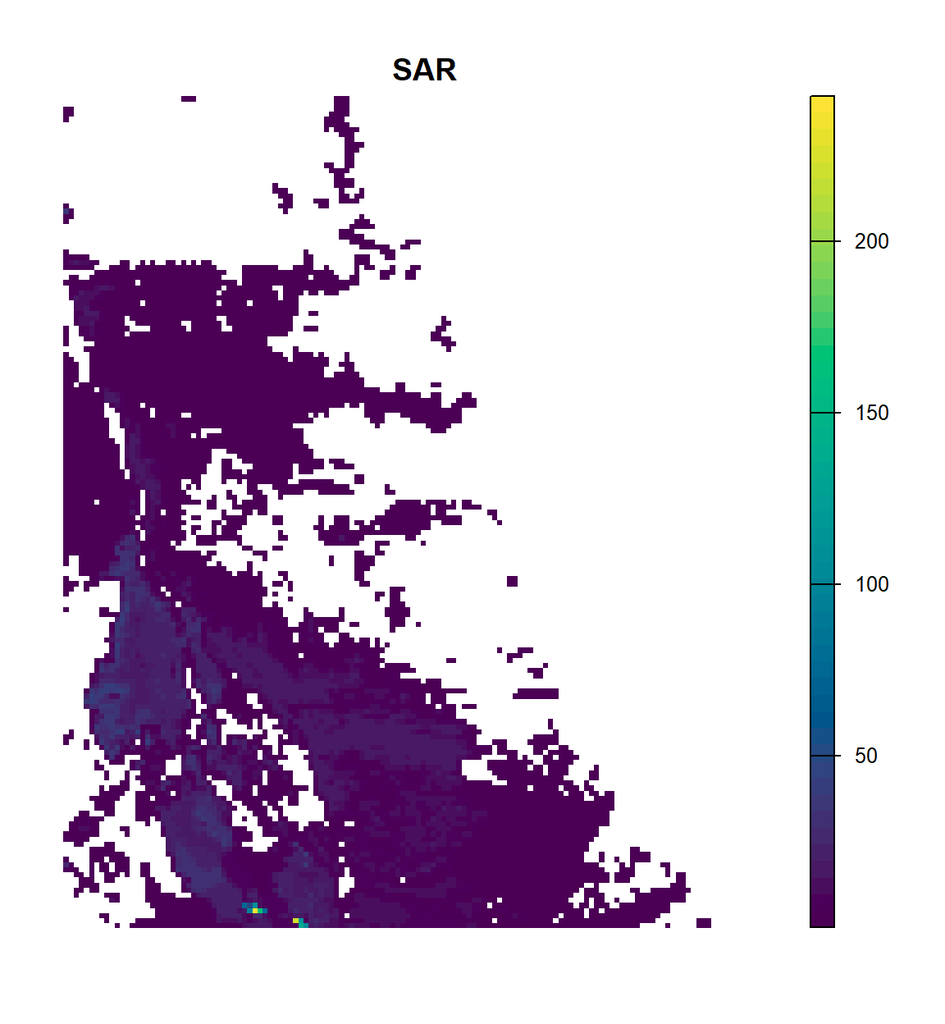

```r
plot(sar, axes = FALSE,  col = hcl.colors(50), main = 'SAR')
```

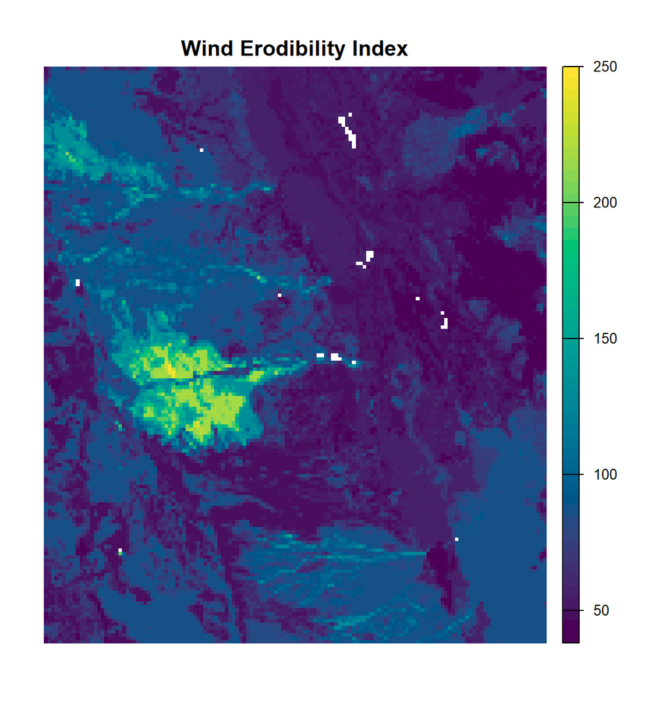

```r
plot(wei, axes = FALSE,  col = hcl.colors(50), main = 'Wind Erodibility Index')
```

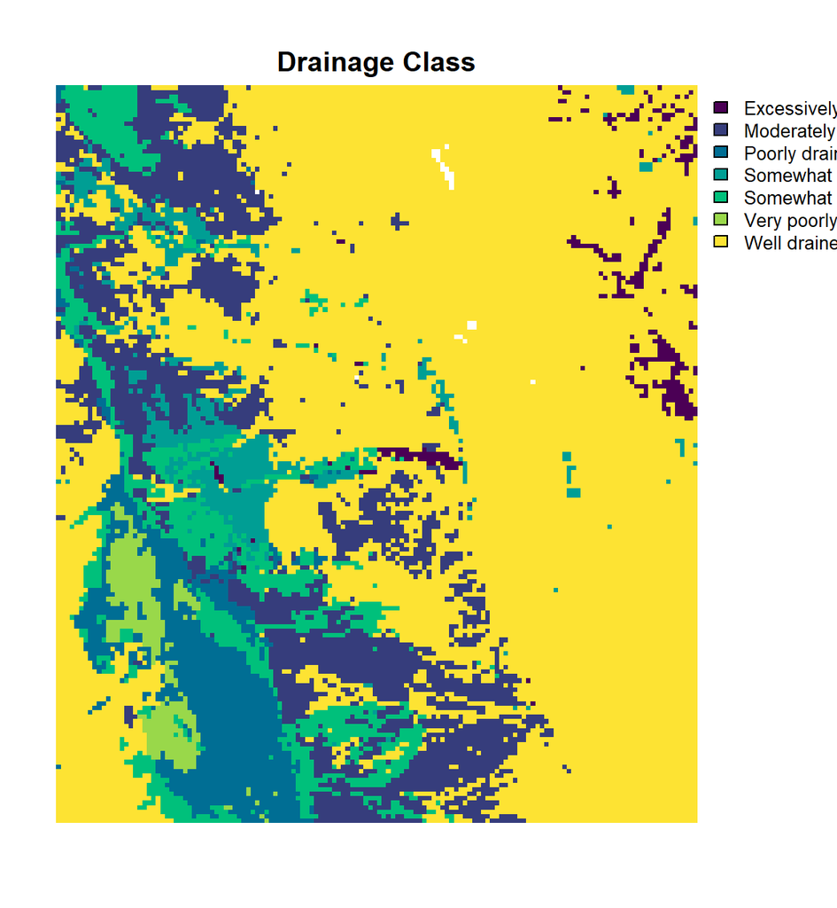

```r
plot(drainage_class, axes = FALSE,  col = hcl.colors(50), main = 'Drainage Class')
```

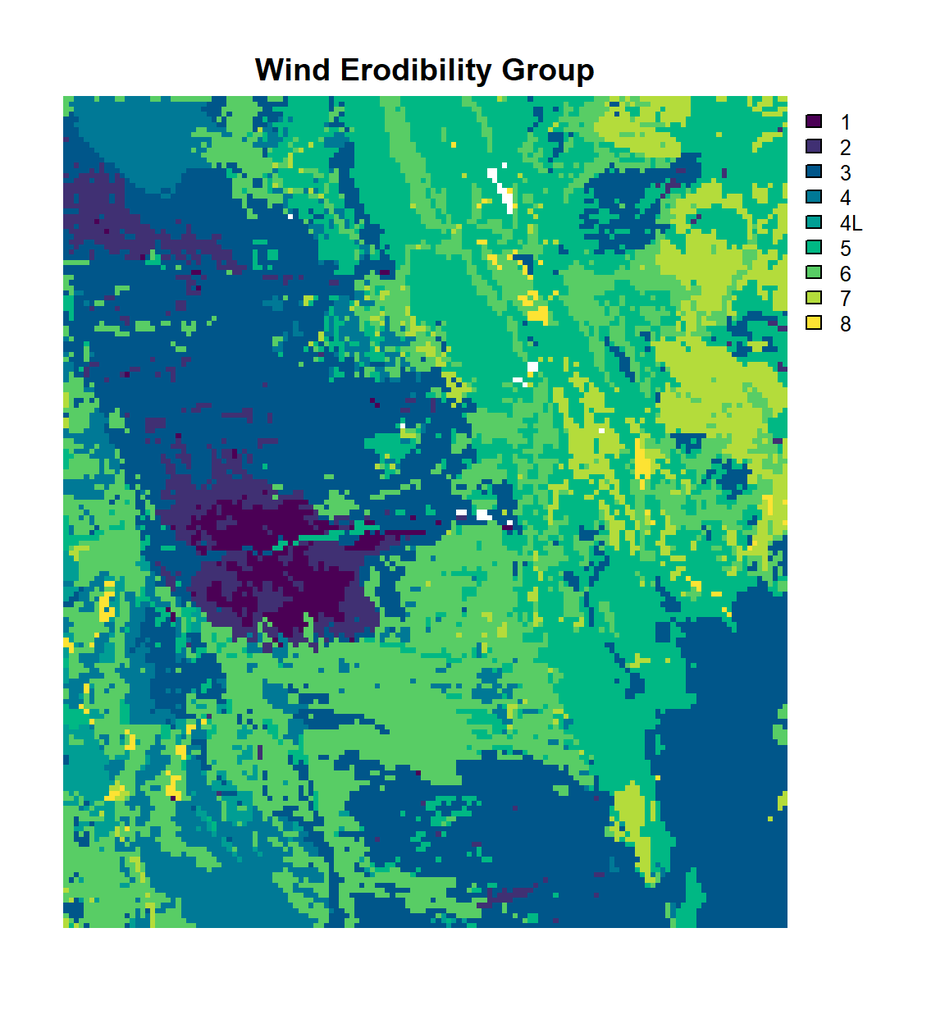

```r
plot(weg, axes = FALSE,  col = hcl.colors(50), main = 'Wind Erodibility Group')
```